# Additives clustering

```r
library(tidyverse)
```

```r
clean_data = read.csv('CLEAN_Additives.csv')
addiives = read.csv('30th_oct-additives_extracted.csv')
additives_info = read.csv('30th_oct-additives_extended.csv')
```

# Data preparation

Full additive list

```r
# Pivot to create dummy variables for each additive
additives_wide_full <- addiives %>%
  mutate(presence = 1) %>%                   # Add a column for presence indicator
  pivot_wider(names_from = additives_detected,
              values_from = presence,
              values_fill = list(presence = 0))  # Fill NAs with 0
```

```r
#Combine raw data and additive dummys
clean_data <- clean_data %>% mutate(upc = as.character(upc))
additives_wide_full <- additives_wide_full %>% mutate(upc = as.character(upc))

full_data <- clean_data %>%
  left_join(additives_wide_full, by = "upc")

dummy_columns <- names(full_data)[names(full_data) %in% names(additives_wide_full)[-1]]
full_data <- full_data %>%
  mutate(across(all_of(dummy_columns), ~ replace_na(.x, 0)))
```

```r
additives_full = full_data
```

Technical effects

```r
effects = addiives %>% rename(Substance = additives_detected) %>%
  left_join(additives_info, by = "Substance")
```

```r
effects = effects %>% select(-c(Substance, is_upf_marker))
```

NB! Leave out duplicated entries. Count technical effects once (i.e if product contains multiple flavouring agents or adjuvants, count it as 1) since we’re interested in the presence/absence of technical effects

```r
effects_no_duplicates <- effects %>%
  distinct(upc, used_for, .keep_all = TRUE)
```

Remove empty strings (technical effect unknown)

```r
effects_no_duplicates = effects_no_duplicates %>%
  filter(used_for != '')
```

```r
# Pivot to create dummy variables for each additive
additives_wide_effects <- effects_no_duplicates %>%
  mutate(presence = 1) %>%                   # Add a column for presence indicator
  pivot_wider(names_from = used_for,
              values_from = presence,
              values_fill = list(presence = 0))  # Fill NAs with 0
```

```r
#Combine raw data and additive dummys
additives_wide_effects <- additives_wide_effects %>% mutate(upc = as.character(upc))

full_data <- clean_data %>%
  left_join(additives_wide_effects, by = "upc")

dummy_columns <- names(full_data)[names(full_data) %in% names(additives_wide_effects)[-1]]
additives_effects <- full_data %>%
  mutate(across(all_of(dummy_columns), ~ replace_na(.x, 0)))
```

# Some further EDA

Top 25 additives

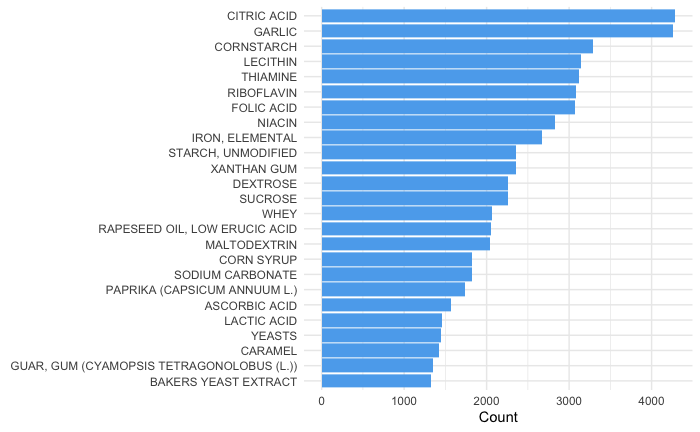

```r
# Calculate column sums
additives_rank <- colSums(additives_full[, 6:502] == 1)

# Convert to data frame
additives_rank <- stack(additives_rank)
names(additives_rank) <- c("value", "name")

# Filter for top 25 values
top_additives_rank <- additives_rank %>%
  arrange(desc(value)) %>%          # Sort by value in descending order
  head(25)                          # Take the top 25

# Create the plot
ggplot(data = top_additives_rank, aes(x = value, y = reorder(name, value))) +
  geom_bar(stat = 'identity', fill = 'steelblue2') +
  xlab('Count') +
  ylab(NULL) +
  theme_minimal()
```

Top 25 technical effects

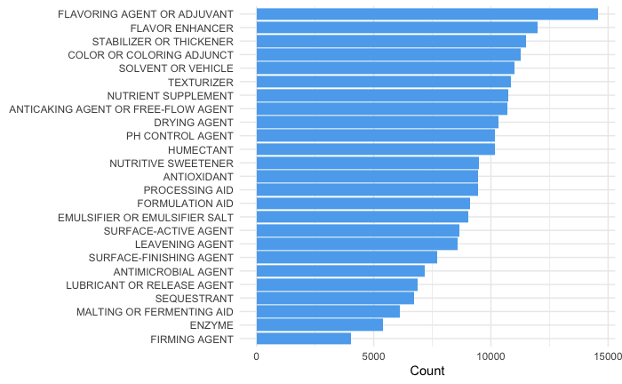

```r
# Calculate column sums
additives_rank <- colSums(additives_effects[, 6:47] == 1)

# Convert to data frame
additives_rank <- stack(additives_rank)
names(additives_rank) <- c("value", "name")

# Filter for top 25 values
top_additives_rank <- additives_rank %>%
  arrange(desc(value)) %>%          # Sort by value in descending order
  head(25)                          # Take the top 25

# Create the plot
ggplot(data = top_additives_rank, aes(x = value, y = reorder(name, value))) +
  geom_bar(stat = 'identity', fill = 'steelblue2') +
  xlab('Count') +
  ylab(NULL) +
  theme_minimal()
```

Explore products with no detected additives

```r
# Calculate row sums for columns that represent additives (6 to 502)
additive_counts <- rowSums(additives_full[, 6:502] == 1)

# Create a new data frame that includes the original data and the additive counts
additives_with_counts <- additives_full %>%
  mutate(additive_count = additive_counts)  # Add a new column for the counts

# Filter for rows where the additive count is 0
no_additives <- additives_with_counts %>%
  filter(additive_count == 0)
```

4157 products contain no additives

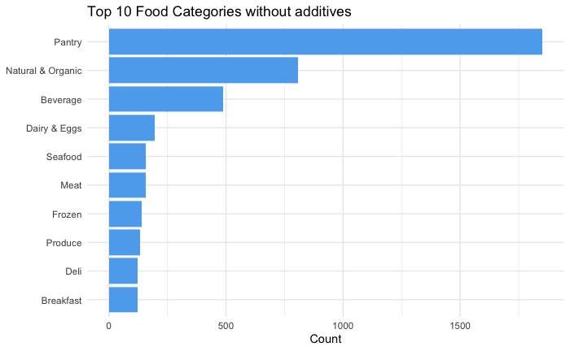

```r
# Create a data frame with category counts
category_counts <- as.data.frame(table(no_additives$category_1))

# Rename columns for clarity
names(category_counts) <- c("category", "count")

# Filter for the most common categories, for example, the top 10
top_categories <- category_counts %>%
  arrange(desc(count)) %>%  # Sort by count in descending order
  head(10)                  # Take the top 10 categories

# Create the plot
ggplot(data = top_categories, aes(x = reorder(category, count), y = count)) +
  geom_bar(stat = 'identity', fill = 'steelblue2') +
  xlab(NULL) +
  ylab('Count') +
  ggtitle('Top 10 Food Categories without additives') +
  coord_flip() +            # Flip coordinates for better readability
  theme_minimal()           # Optional: apply a minimal theme
```

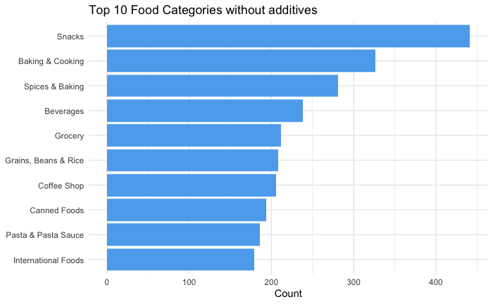

```r
# Create a data frame with category counts
category_counts <- as.data.frame(table(no_additives$category_2))

# Rename columns for clarity
names(category_counts) <- c("category", "count")

# Filter for the most common categories, for example, the top 10
top_categories <- category_counts %>%
  arrange(desc(count)) %>%  # Sort by count in descending order
  head(10)                  # Take the top 10 categories

# Create the plot
ggplot(data = top_categories, aes(x = reorder(category, count), y = count)) +
  geom_bar(stat = 'identity', fill = 'steelblue2') +
  xlab(NULL) +
  ylab('Count') +
  ggtitle('Top 10 Food Categories without additives') +
  coord_flip() +            # Flip coordinates for better readability
  theme_minimal()           # Optional: apply a minimal theme
```

Examining the dataset no_additives manually shows that most products in snacks category refer to things such as nuts, dried fruits, etc. Some additives across products have been missed due to ambiguous names (enzyme, natural flavoring, color added). Some products containing hydrogenated oils have not been detected due to ambiguous noting (Hydrogenated oils : soybean, sunflower). For current purposes, this list will remain as it is, matching is good enough. Option is also to manually go through the list and correct wrongly detected items. This is too labour intensive for current purposes due to the unimaginable combination of possible reportings.

I will proceed with assuming that the list of products without additives is representative of the population we’re interested in.

### General methodology

(Outlier detection) (Dimension reduction using MCA) Cluster between K = 2…10 (K-modes or K-means) Pick the best clustering configuration based on Average Silhouette Width Assess cluster stability (write a bootstrap algorithm yourself?)

# K-modes on full data regarding additive effects

```r
library(cluster)
library(klaR)
library(fpc)
```

```r
clustering_modes = kmodes(data = additives_effects[, 6:47], modes = 5, fast = TRUE)
```

```r
sil_modes = silhouette(clustering_modes$cluster, dist(additives_effects[, 6:47], method = 'manhattan'))
```

```r
summary(sil_modes)
```

```
Silhouette of 20064 units in 5 clusters from silhouette.default(x = clustering_modes$cluster, dist = dist(additives_effects[, 6:47], method = "manhattan")) :
 Cluster sizes and average silhouette widths:
      3019       2064       8485       3734       2762
0.08058337 0.20565134 0.65474375 0.09156233 0.20592516
Individual silhouette widths:
   Min. 1st Qu.  Median    Mean 3rd Qu.    Max.
-0.3688  0.1137  0.2642  0.3556  0.7544  0.8147
```

```r
mean(sil_modes[, 'sil_width'])
```

```
[1] 0.3555575
```

```r
start = Sys.time()
set.seed(42)

sil_scores = numeric(10)

for (k in 2:11) {
  clustering_modes = kmodes(data = additives_effects[, 6:47], modes = k, fast = TRUE)
  sil_modes = silhouette(clustering_modes$cluster, dist(additives_effects[, 6:47], method = 'manhattan'))
  sil_scores[k-1] = mean(sil_modes[, 'sil_width'])
}

end = Sys.time()
difference = start - end
```

Parallel implementation for future purposes

```r
num_cores <- detectCores()   # Use one less than the total number of cores
cl <- makeCluster(num_cores)     # Create a cluster
registerDoParallel(cl)            # Register the cluster for parallel processing

start <- Sys.time()              # Record start time
set.seed(42)                     # Set seed for reproducibility

# Run the silhouette score computations in parallel using foreach
sil_scores <- foreach(k = 1:10, .combine = c) %dopar% {
  clustering_modes <- kmodes(data = additives_effects[, 6:47], modes = k, fast = TRUE)
  sil_modes <- silhouette(clustering_modes$cluster, dist(additives_effects[, 6:47], method = 'manhattan'))
  mean(sil_modes[, 'sil_width'])  # Return mean silhouette width
}

stopCluster(cl)                    # Stop the cluster

end <- Sys.time()                  # Record end time
difference <- end - start          # Calculate time difference
```

```r
difference
```

[output not shown]

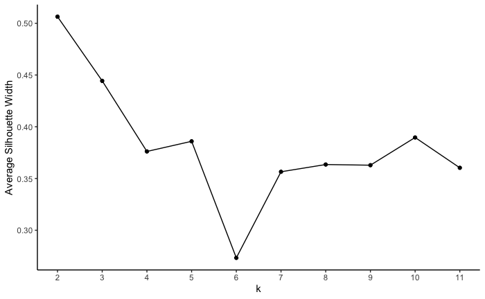

```r
for_plot = data.frame(
  k = seq(2, 11),
  sil_score = sil_scores
)

ggplot(data = for_plot, aes(x = k, y = sil_score)) + geom_line() + theme_classic() +
  ylab("Average Silhouette Width") + xlab("k") + scale_x_continuous(breaks = seq(2, 11, by = 1)) + geom_point()
```

Simply splitting the data appears to provide better clustering than detecting subgroups. Let’s compare the results from keeping 2 or 3 clusters.

```r
set.seed(42)
two_clusters = kmodes(data = additives_effects[, 6:47], modes = 2, fast = TRUE)
three_clusters = kmodes(data = additives_effects[, 6:47], modes = 3, fast = TRUE)
```

```r
additives_effects$clusters_2 = two_clusters$cluster
additives_effects$clusters_3 = three_clusters$cluster
```

```r
table(additives_effects$clusters_2)
```

```
    1     2
 9614 10450
```

```r
table(additives_effects$clusters_3)
```

```
   1    2    3
9186 8676 2202
```

The data appears to be split best into roughly two equally sized clusters, with the possibility of adding a smaller third cluster.

```r
table(additives_effects$clusters_2, additives_effects$clusters_3)
```

```
       1    2    3
  1    0 8676  938
  2 9186    0 1264
```

The third cluster borrows from both the first and the second clusters.

Examine technical effects per cluster

```
$`1`

$`2`
```

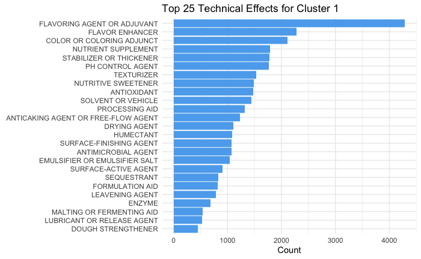

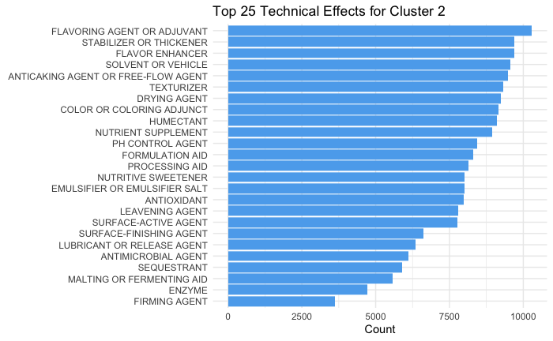

```r
# Create a list to store plots for each cluster
cluster_plots <- list()

# Loop through each unique cluster
for (cluster in unique(additives_effects$clusters_2)) {

  # Filter the data for the current cluster
  cluster_data <- additives_effects[additives_effects$clusters_2 == cluster, ]

  # Calculate column sums for technical effect columns
  additives_rank <- colSums(cluster_data[, 6:47] == 1)

  # Convert to data frame and arrange to get the top 25 effects
  additives_rank_df <- stack(additives_rank) %>%
    arrange(desc(values)) %>%
    head(25)

  # Rename columns for clarity
  names(additives_rank_df) <- c("value", "name")

  # Create the plot for the current cluster
  p <- ggplot(data = additives_rank_df, aes(x = value, y = reorder(name, value))) +
    geom_bar(stat = 'identity', fill = 'steelblue2') +
    xlab('Count') +
    ylab(NULL) +
    theme_minimal() +
    ggtitle(paste("Top 25 Technical Effects for Cluster", cluster))

  # Store the plot in the list
  cluster_plots[[as.character(cluster)]] <- p
}

# To display a plot, you can use print(cluster_plots[[<cluster_number>]]) for specific clusters,
# or display all at once
cluster_plots
```

```
$`2`

$`3`

$`1`
```

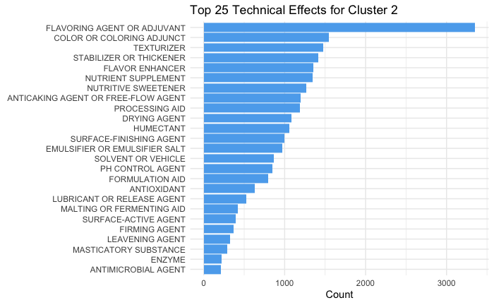

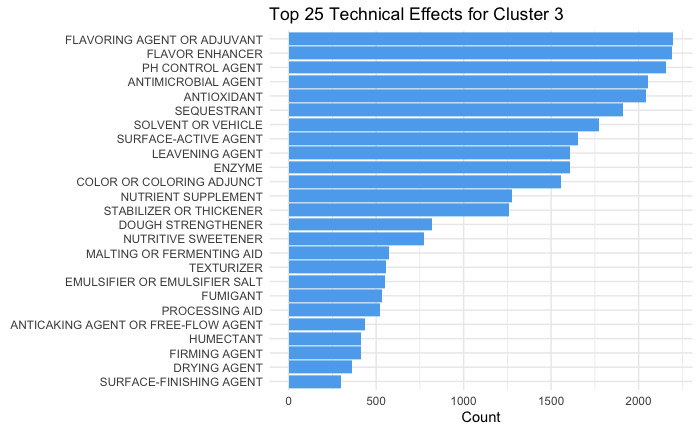

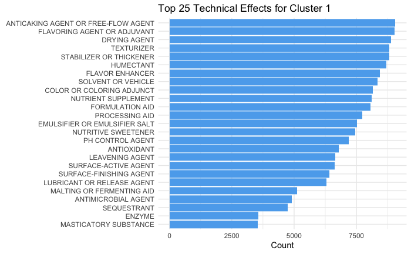

```r
# Create a list to store plots for each cluster
cluster_plots <- list()

# Loop through each unique cluster
for (cluster in unique(additives_effects$clusters_3)) {

  # Filter the data for the current cluster
  cluster_data <- additives_effects[additives_effects$clusters_3 == cluster, ]

  # Calculate column sums for technical effect columns
  additives_rank <- colSums(cluster_data[, 6:47] == 1)

  # Convert to data frame and arrange to get the top 25 effects
  additives_rank_df <- stack(additives_rank) %>%
    arrange(desc(values)) %>%
    head(25)

  # Rename columns for clarity
  names(additives_rank_df) <- c("value", "name")

  # Create the plot for the current cluster
  p <- ggplot(data = additives_rank_df, aes(x = value, y = reorder(name, value))) +
    geom_bar(stat = 'identity', fill = 'steelblue2') +
    xlab('Count') +
    ylab(NULL) +
    theme_minimal() +
    ggtitle(paste("Top 25 Technical Effects for Cluster", cluster))

  # Store the plot in the list
  cluster_plots[[as.character(cluster)]] <- p
}

# To display a plot, you can use print(cluster_plots[[<cluster_number>]]) for specific clusters,
# or display all at once
cluster_plots
```

Clusters appear to emerge based on the amount of technical effects applied to a product. Differences in the technical effects also appear. Let’s examine how the categories of food and the amount of upf-markers per cluster appear.

```
$`1`

$`2`
```

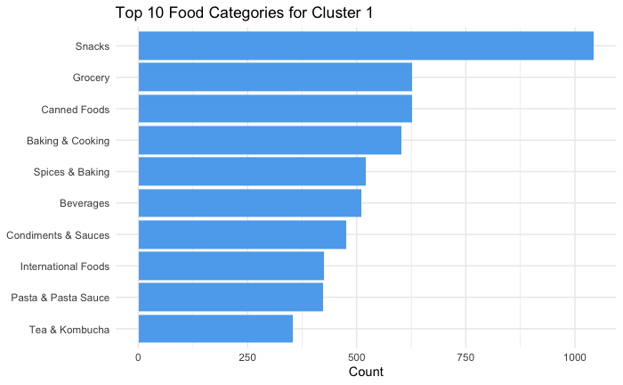

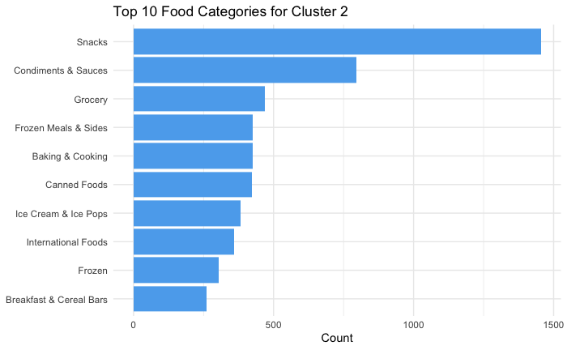

```r
# Create a list to store plots for each cluster
category_plots <- list()

# Loop through each unique cluster
for (cluster in unique(additives_effects$clusters_2)) {

  # Filter the data for the current cluster
  cluster_data <- additives_effects[additives_effects$clusters_2 == cluster, ]

  # Calculate category counts for category_2
  category_counts <- as.data.frame(table(cluster_data$category_2))

  # Rename columns for clarity
  names(category_counts) <- c("category", "count")

  # Filter for the top 10 most common categories
  top_categories <- category_counts %>%
    arrange(desc(count)) %>%
    head(10)

  # Create the plot for the current cluster
  p <- ggplot(data = top_categories, aes(x = reorder(category, count), y = count)) +
    geom_bar(stat = 'identity', fill = 'steelblue2') +
    xlab(NULL) +
    ylab('Count') +
    ggtitle(paste('Top 10 Food Categories for Cluster', cluster)) +
    coord_flip() +
    theme_minimal()

  # Store the plot in the list
  category_plots[[as.character(cluster)]] <- p
}

# To display a plot, you can use print(category_plots[[<cluster_number>]]) for specific clusters,
# or display all at once
category_plots
```

```
$`2`

$`3`

$`1`
```

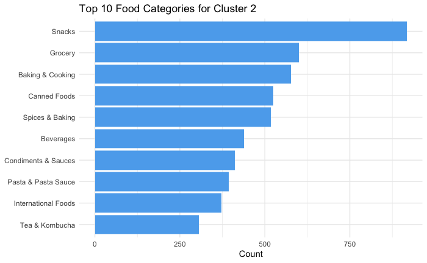

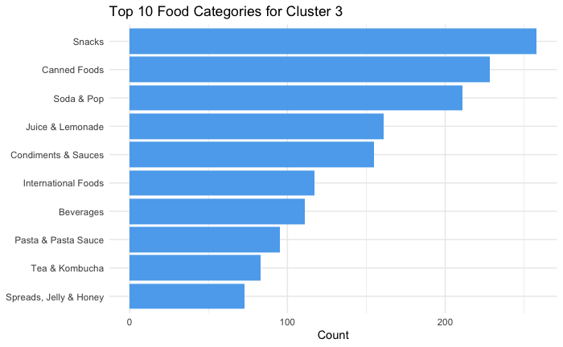

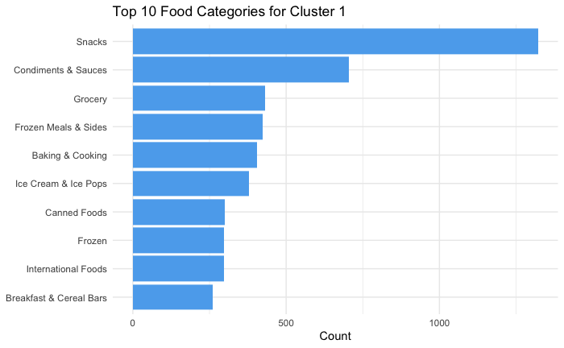

```r
# Create a list to store plots for each cluster
category_plots <- list()

# Loop through each unique cluster
for (cluster in unique(additives_effects$clusters_3)) {

  # Filter the data for the current cluster
  cluster_data <- additives_effects[additives_effects$clusters_3 == cluster, ]

  # Calculate category counts for category_2
  category_counts <- as.data.frame(table(cluster_data$category_2))

  # Rename columns for clarity
  names(category_counts) <- c("category", "count")

  # Filter for the top 10 most common categories
  top_categories <- category_counts %>%
    arrange(desc(count)) %>%
    head(10)

  # Create the plot for the current cluster
  p <- ggplot(data = top_categories, aes(x = reorder(category, count), y = count)) +
    geom_bar(stat = 'identity', fill = 'steelblue2') +
    xlab(NULL) +
    ylab('Count') +
    ggtitle(paste('Top 10 Food Categories for Cluster', cluster)) +
    coord_flip() +
    theme_minimal()

  # Store the plot in the list
  category_plots[[as.character(cluster)]] <- p
}

# To display a plot, you can use print(category_plots[[<cluster_number>]]) for specific clusters,
# or display all at once
category_plots
```

Cluster 3 provides meaningful differences. It appears to differentiate further between technical effects applied to beverages and canned foods.

```r
effects = addiives %>% rename(Substance = additives_detected) %>%
  left_join(additives_info, by = "Substance")
```

```r
effects <- effects %>%
  filter(is_upf_marker == "Yes") %>%
  distinct(upc, .keep_all = TRUE)
```

```r
effects = effects[, c(1, 4)]
```

```r
effects <- effects %>% mutate(upc = as.character(upc))
additives_effects = additives_effects %>%
  left_join(effects, by = 'upc')
```

```r
additives_effects$is_upf_marker[is.na(additives_effects$is_upf_marker)] <- "No"
```

```r
table(additives_effects$clusters_2, additives_effects$is_upf_marker)
```

```
       No   Yes
  1  6428  3186
  2   194 10256
```

Based on the two cluster configuration, the first cluster contains predominantly products with no additives indicating ultra-processing, whereas the opposite is true for the second cluster.

```r
table(additives_effects$clusters_3, additives_effects$is_upf_marker)
```

```
      No  Yes
  1  122 9064
  2 6107 2569
  3  393 1809
```

The three cluster configuration also finds the large cluster with products that have not undergone ultra-processing, with further distinguishing between two more processed groups.

Now let’s examine a random sample of products from these cluster configurations.

```r
random_samples <- additives_effects %>%
  group_by(clusters_2) %>%
  slice_sample(n = 50, replace = FALSE) %>%  # Sample 50 products without replacement
  ungroup()

random_samples %>% filter(clusters_2 == 1) %>% dplyr::select(product_name, category_2)
```

| product_name | category_2 |
| --- | --- |
| Ty Ling Pure Sesame Oil | International Foods |
| Boar's Head Kosher Whole Dill Pickles | Hummus, Salsa, Dips & Snacks |
| Sunkist® Cherry Limeade Soda Cans | Soda & Pop |
| Monari Federzoni Organic Balsamic Vinegar of Modena | Baking & Cooking |
| Dr. Mcdougall's Organic Lower Sodium French Lentil Soup | Canned Foods |
| Kroger® Blackened Seasoning | Spices & Seasonings |
| Sweet Logic Lemon Poppy Seed Mug Cake (5-Pack) | Baking & Cooking |
| Stick Beverages Green Tea Sticks | Beverages |
| Crown Prince Natural Wild Caught Brisling Sardines Mediterranean Style | Canned Seafood |
| R.W. Knudsen Just Cranberry Juice | Beverages |

[output cut: 40 more lines]

```r
random_samples %>% filter(clusters_2 == 2) %>% dplyr::select(product_name, category_2)
```

| product_name | category_2 |
| --- | --- |
| Mission Super Soft Yellow Corn Tortillas | International Foods |
| Kroger® Pretzel Sticks | Snacks |
| Blue Diamond® Bold Wasabi & Soy Sauce Almonds | Nuts |
| Hippie Snacks Cheeze Cauliflower Crisps | Grocery |
| Activia® Peach Lowfat Probiotic Yogurt | Yogurt |
| Cool Whip Extra Creamy Whipped Cream Topping | Frozen Desserts & Pies |
| Marzetti Dill Veggie Dip | Dips & Dressings |
| Gardein® Plant-Based Chili With Beans | Canned Foods |
| Tofurky Meatless Italian Deli Slices | Dairy & Eggs |
| Totino's Supreme Party Pizza Pack Thin Crust Frozen Pizza Snacks | Frozen Pizza |

[output cut: 40 more lines]

```r
random_samples <- additives_effects %>%
  group_by(clusters_3) %>%
  slice_sample(n = 50, replace = FALSE) %>%  # Sample 50 products without replacement
  ungroup()

random_samples %>% filter(clusters_3 == 1) %>% dplyr::select(product_name, category_2)
```

| product_name | category_2 |
| --- | --- |
| Crystal Light Liquid Blueberry Raspberry Naturally Flavored Drink Mix | Drink Mixes & Beverage Enhancers |
| Hillshire Farm® Turkey Smoked Sausage | Dinner Sausage |
| Sara Lee Delightful White made with Whole Grain Keto Friendly Bread | Packaged Bread, Buns, and Rolls |
| Rudi's Gluten-Free Original Sandwich Bread | Frozen |
| Earth Balance® Soy Free Buttery Spread With Olive Oil Tub | Butter & Margarine |
| Kroger® Spicy Yum Yum Sauce | Condiments & Sauces |
| Mission® Carb Balance® Low Carb Whole Wheat Soft Taco Tortillas | International Foods |
| Annie’s Organic White Cheddar Microwave Mac N Cheese Macaroni and Cheese Dinner Cup | Packaged Meals & Sides |
| Kroger® Wild Caught Crunchy Popcorn Shrimp | Breaded Shrimp |
| Cousin Willie's Movie Theater Butter Microwave Popcorn | Snacks |

[output cut: 40 more lines]

```r
random_samples %>% filter(clusters_3 == 2) %>% dplyr::select(product_name, category_2)
```

| product_name | category_2 |
| --- | --- |
| Morton® Nature's Seasons® Seasoning Blend | Spices & Seasonings |
| Ugly Mug Buttermoon Ground Coffee | Coffee Shop |
| Kroger® Ground Thyme | Spices & Seasonings |
| DOLE® Sliced Peaches in 100% Fruit Juice | Snacks |
| Petite Roasted Unsalted Cashews | Snacks |
| Woodstock Farms Unsalted Creamy Almond Butter | Spreads, Jelly & Honey |
| Kroger® Wide Egg Noodles | Pasta & Pasta Sauce |
| Westsoy Organic Unsweetened Soy Milk | Dairy & Eggs |
| Back to Nature Peanut Butter Granola Clusters | Grocery |
| Eden Sprouted Brown Mochi Rice | Grains, Beans & Rice |

[output cut: 40 more lines]

```r
random_samples %>% filter(clusters_3 == 3) %>% dplyr::select(product_name, category_2)
```

| product_name | category_2 |
| --- | --- |
| Mrs. Dash Extra Spicy Seasoning Blend | Spices & Seasonings |
| Simple Truth Organic™ Cracked Black Pepper Flavored Beef Jerky Bag | Snacks |
| KIND Kids Chewy Peanut Butter Chocolate Chip Granola Bars | Grocery |
| Kroger® Maraschino Cherries with Stems | Canned Foods |
| Knouse Foods Musselman's Sweetened Apple Sauce | Snacks |
| Capri Sun Pacific Cooler Mixed Fruit Juice Box Pouches | Drink Boxes & Pouches |
| Kroger® Original Vanilla Wafers | Snacks |
| Stonewall Kitchen Black Bean Salsa | Condiments & Sauces |
| Kroger® Classic Applesauce | Snacks |
| Big K® Dr. K Cola Soda Cans Limits May Apply | Soda & Pop |

[output cut: 40 more lines]

Let’s also examine clusters based on the additives they contain.

```r
additives_full$clusters_2 = additives_effects$clusters_2
additives_full$clusters_3 = additives_effects$clusters_3
```

```
$`2`

$`3`

$`1`
```

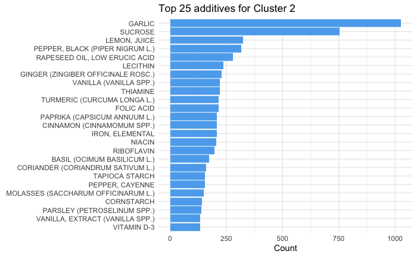

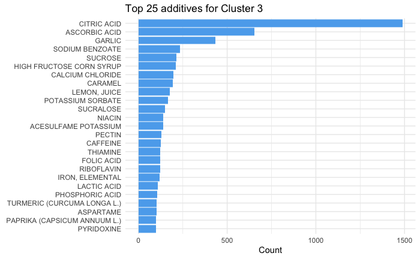

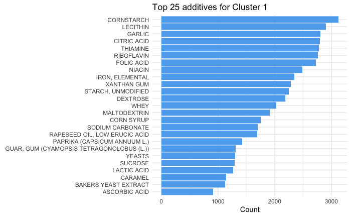

```r
# Create a list to store plots for each cluster
cluster_plots <- list()

# Loop through each unique cluster
for (cluster in unique(additives_full$clusters_3)) {

  # Filter the data for the current cluster
  cluster_data <- additives_full[additives_full$clusters_3 == cluster, ]
  additives_rank <- colSums(cluster_data[, 6:502] == 1)

  # Convert to data frame and arrange to get the top 25 effects
  additives_rank_df <- stack(additives_rank) %>%
    arrange(desc(values)) %>%
    head(25)

  # Rename columns for clarity
  names(additives_rank_df) <- c("value", "name")

  # Create the plot for the current cluster
  p <- ggplot(data = additives_rank_df, aes(x = value, y = reorder(name, value))) +
    geom_bar(stat = 'identity', fill = 'steelblue2') +
    xlab('Count') +
    ylab(NULL) +
    theme_minimal() +
    ggtitle(paste("Top 25 additives for Cluster", cluster))

  # Store the plot in the list
  cluster_plots[[as.character(cluster)]] <- p
}

# To display a plot, you can use print(cluster_plots[[<cluster_number>]]) for specific clusters,
# or display all at once
cluster_plots
```

```
$`1`

$`2`
```

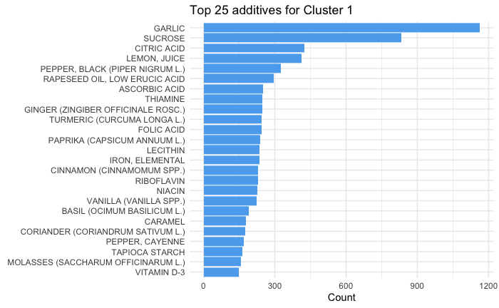

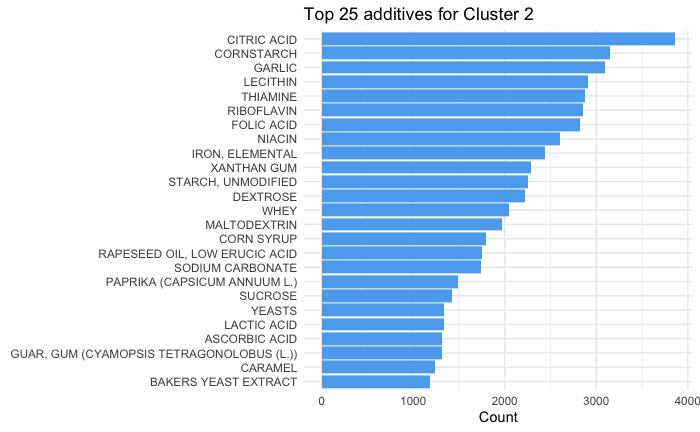

```r
# Create a list to store plots for each cluster
cluster_plots <- list()

# Loop through each unique cluster
for (cluster in unique(additives_full$clusters_2)) {

  # Filter the data for the current cluster
  cluster_data <- additives_full[additives_full$clusters_2 == cluster, ]
  additives_rank <- colSums(cluster_data[, 6:502] == 1)

  # Convert to data frame and arrange to get the top 25 effects
  additives_rank_df <- stack(additives_rank) %>%
    arrange(desc(values)) %>%
    head(25)

  # Rename columns for clarity
  names(additives_rank_df) <- c("value", "name")

  # Create the plot for the current cluster
  p <- ggplot(data = additives_rank_df, aes(x = value, y = reorder(name, value))) +
    geom_bar(stat = 'identity', fill = 'steelblue2') +
    xlab('Count') +
    ylab(NULL) +
    theme_minimal() +
    ggtitle(paste("Top 25 additives for Cluster", cluster))

  # Store the plot in the list
  cluster_plots[[as.character(cluster)]] <- p
}

# To display a plot, you can use print(cluster_plots[[<cluster_number>]]) for specific clusters,
# or display all at once
cluster_plots
```

Most interesting result from this clustering exercise is the finding that without using the column ‘is_upf_marker’, clusters that pertain to this indicator can nevertheless be identified. Seems to come down to the observation that highly processed foods use more additives and especially those that indicate ultra-processing.

Let’s try to explore the stability of the cluster configurations.

```r
kmodesCBI = function(data = data, k = 3) {
  clustering = kmodes(data = data, modes = k, fast = TRUE)

  data$cluster = clustering$cluster
  cluster_membership_list <- lapply(unique(data$cluster), function(cl) {
    data$cluster == cl
    })
  names(cluster_membership_list) <- as.character(unique(data$cluster))

  out = list(
    result = clustering$cluster,
    nc = k,
    clusterlist = cluster_membership_list,
    partition = clustering$cluster,
    clustermethod = 'kmodes'
  )
}
```

```r
stability_eval = clusterboot(data = additives_effects[, 6:47], B = 5, bootmethod = 'boot',
                             clustermethod = kmodesCBI)
```

```
boot 1
```

```
boot 2
```

```
boot 3
```

```
boot 4
```

```
boot 5
```

```r
print(stability_eval)
```

```
* Cluster stability assessment *
Cluster method:  kmodes
Full clustering results are given as parameter result
of the clusterboot object, which also provides further statistics
of the resampling results.
Number of resampling runs:  5

Number of clusters found in data:  3

 Clusterwise Jaccard bootstrap (omitting multiple points) mean:
[1] 0.9033584 0.4669221 0.7091405
dissolved:
[1] 0 3 0
recovered:
[1] 5 2 2
```

# Dimension reduction

Outlier detection, detect columns with less than 10% prevalence

```r
options(scipen=999)
colmeans = sapply(additives_full[, 6:502], mean)
outliers = colmeans[colmeans < 0.1]
length(outliers)
```

```
[1] 481
```

```r
sort(colmeans, decreasing = TRUE)[1:25]
```

```
                               CITRIC ACID                                     GARLIC                                 CORNSTARCH
                                0.21351675                                 0.21251994                                 0.16382576
                                  LECITHIN                                   THIAMINE                                 RIBOFLAVIN
                                0.15684809                                 0.15570175                                 0.15350877
                                FOLIC ACID                                     NIACIN                            IRON, ELEMENTAL
                                0.15291069                                 0.14109848                                 0.13302432
                        STARCH, UNMODIFIED                                XANTHAN GUM                                   DEXTROSE
                                0.11767344                                 0.11742424                                 0.11288876
                                   SUCROSE                                       WHEY              RAPESEED OIL, LOW ERUCIC ACID
                                0.11273923                                 0.10316986                                 0.10207337
                              MALTODEXTRIN                                 CORN SYRUP                           SODIUM CARBONATE
                                0.10142544                                 0.09100877                                 0.09085925
              PAPRIKA (CAPSICUM ANNUUM L.)                              ASCORBIC ACID                                LACTIC ACID
                                0.08637360                                 0.07800040                                 0.07241826
                                    YEASTS                                    CARAMEL  GUAR, GUM (CYAMOPSIS TETRAGONOLOBUS (L.))
                                0.07216906                                 0.07077352                                 0.06743421
                      BAKERS YEAST EXTRACT
                                0.06598884
```

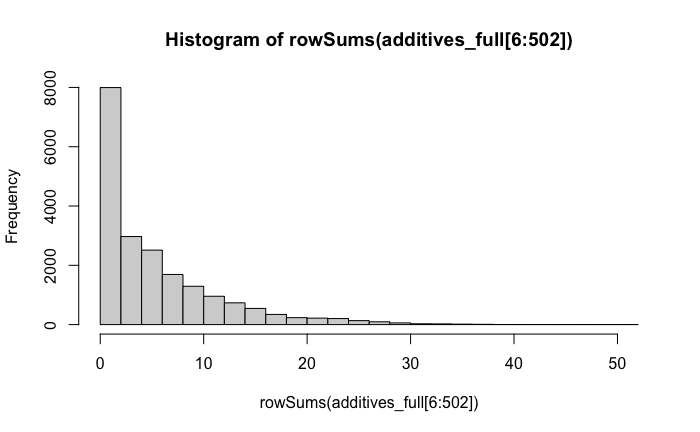

```r
hist(rowSums(additives_full[6:502]), breaks = 30)
```

While most products contain additives, they contain a few different additives and hence it is likely difficult to cluster them based on additive information alone. Hence why clustering based on technical effects is more reasonable.

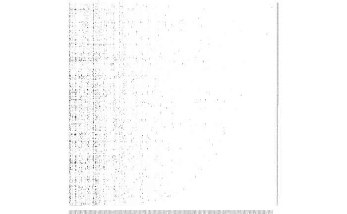

```r
#sample(nrow(additives_full), 5000)
heatmap(as.matrix(additives_full[, 6:502]),
        col = c("white", "black"),
        scale = "none",
        Rowv = NA,
        Colv = NA,
        margins = c(1, 1),  # Adjust margins if needed
        xlab = NULL,
        ylab = NULL,
        labCol = NULL,
        labRow = NULL,
        cexRow = 0.1,
        cexCol = 0.1)
```

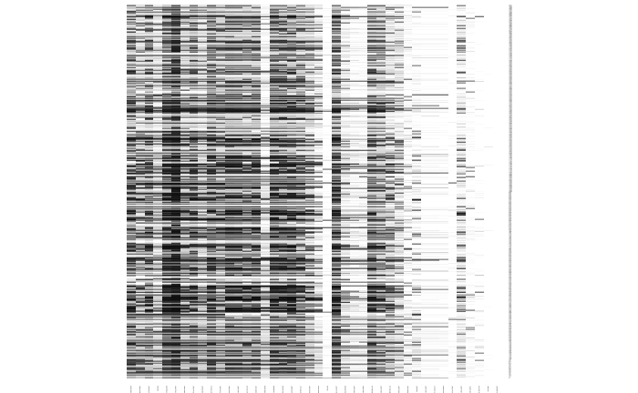

```r
heatmap(as.matrix(additives_effects[, 6:47]),
        col = c("white", "black"),
        scale = "none",
        Rowv = NA,
        Colv = NA,
        margins = c(1, 1),  # Adjust margins if needed
        xlab = NULL,
        ylab = NULL,
        labCol = NULL,
        labRow = NULL,
        cexRow = 0.1,
        cexCol = 0.1)
```

```r
colmeans = sapply(additives_effects[, 6:47], mean)
outliers = colmeans[colmeans < 0.05]
length(outliers)
```

```
[1] 9
```

```r
effects_wo_outliers = additives_effects %>% dplyr::select(-names(outliers))
```

```r
sort(colmeans, decreasing = TRUE)
```

```
         FLAVORING AGENT OR ADJUVANT                      FLAVOR ENHANCER              STABILIZER OR THICKENER
                        0.7269736842                         0.5974880383                         0.5722188995
           COLOR OR COLORING ADJUNCT                   SOLVENT OR VEHICLE                           TEXTURIZER
                        0.5618520734                         0.5482954545                         0.5403708134
                 NUTRIENT SUPPLEMENT  ANTICAKING AGENT OR FREE-FLOW AGENT                         DRYING AGENT
                        0.5349381978                         0.5330940989                         0.5151515152
                    PH CONTROL AGENT                            HUMECTANT                  NUTRITIVE SWEETENER
                        0.5078249601                         0.5073763955                         0.4731359649
                         ANTIOXIDANT                       PROCESSING AID                      FORMULATION AID
                        0.4717902711                         0.4710925040                         0.4547448166
       EMULSIFIER OR EMULSIFIER SALT                 SURFACE-ACTIVE AGENT                      LEAVENING AGENT
                        0.4506578947                         0.4320673844                         0.4278309410
             SURFACE-FINISHING AGENT                  ANTIMICROBIAL AGENT           LUBRICANT OR RELEASE AGENT
                        0.3837719298                         0.3579545455                         0.3433014354
                         SEQUESTRANT            MALTING OR FERMENTING AID                               ENZYME
                        0.3349780702                         0.3043759968                         0.2690889155
                       FIRMING AGENT                MASTICATORY SUBSTANCE              NON-NUTRITIVE SWEETENER
                        0.2013058214                         0.1913875598                         0.1905402711
                  DOUGH STRENGTHENER             CURING OR PICKLING AGENT                 FLOUR TREATING AGENT
                        0.1886961722                         0.1622807018                         0.1158791866
         OXIDIZING OR REDUCING AGENT                             FUMIGANT                           PROPELLANT
                        0.1039174641                         0.0947966507                         0.0629485646
           FREEZING OR COOLING AGENT                       DIRECT CONTACT                           PROCESSING
                        0.0349381978                         0.0349381978                         0.0299541467
         LUBRICANT OR RELEASE AGENT,                               TRACER                BOILER WATER ADDITIVE
                        0.0208333333                         0.0196371611                         0.0132575758
    WASHING OR SURFACE REMOVAL AGENT                              SOLVENT                            SYNERGIST
                        0.0061303828                         0.0009469697                         0.0000000000
```

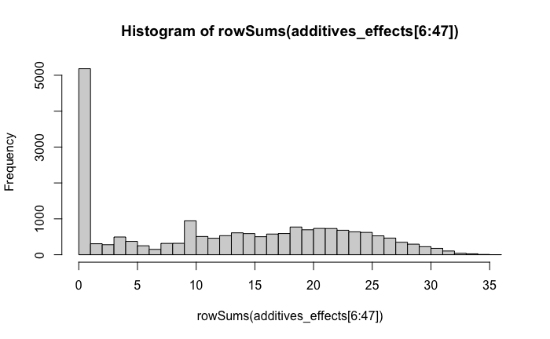

```r
hist(rowSums(additives_effects[6:47]), breaks = 30)
```

```r
library(FactoMineR)
```

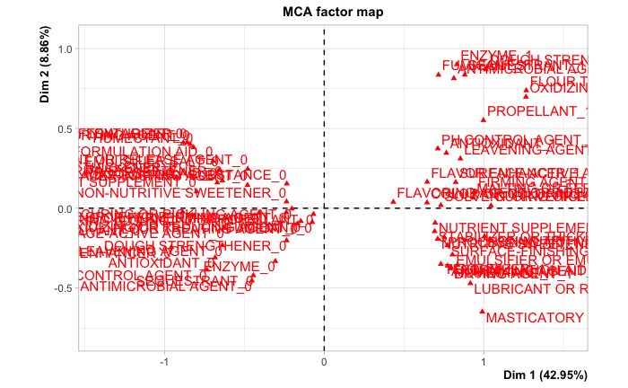

[figure not shown]

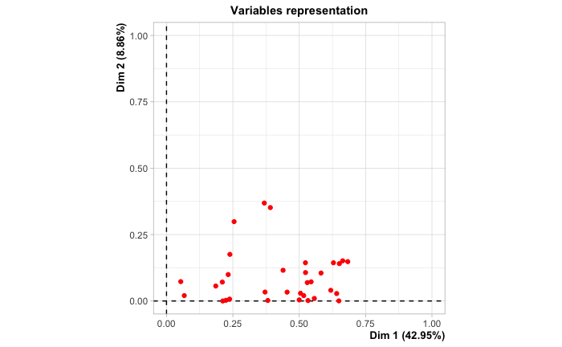

```r
effects_wo_outliers[, 6:38] <- lapply(effects_wo_outliers[, 6:38], factor)
dim_reduction = MCA(effects_wo_outliers[, 6:38])
```

```r
dim_reduction$eig
```

```
         eigenvalue percentage of variance cumulative percentage of variance
dim 1  0.4295026718            42.95026718                          42.95027
dim 2  0.0886337450             8.86337450                          51.81364
dim 3  0.0646173787             6.46173787                          58.27538
dim 4  0.0436505972             4.36505972                          62.64044
dim 5  0.0371828588             3.71828588                          66.35873
dim 6  0.0313534081             3.13534081                          69.49407
dim 7  0.0280162218             2.80162218                          72.29569
dim 8  0.0265011473             2.65011473                          74.94580
dim 9  0.0235955941             2.35955941                          77.30536
dim 10 0.0226336167             2.26336167                          79.56872
dim 11 0.0213596021             2.13596021                          81.70468
dim 12 0.0194737058             1.94737058                          83.65205
dim 13 0.0159641666             1.59641666                          85.24847
dim 14 0.0141225654             1.41225654                          86.66073
dim 15 0.0127565329             1.27565329                          87.93638
dim 16 0.0122502571             1.22502571                          89.16141
dim 17 0.0110119049             1.10119049                          90.26260
dim 18 0.0103812359             1.03812359                          91.30072
dim 19 0.0096707845             0.96707845                          92.26780
dim 20 0.0086443955             0.86443955                          93.13224
dim 21 0.0082096212             0.82096212                          93.95320
dim 22 0.0079898291             0.79898291                          94.75218
dim 23 0.0073340172             0.73340172                          95.48559
dim 24 0.0069438383             0.69438383                          96.17997
dim 25 0.0064188914             0.64188914                          96.82186
dim 26 0.0060579746             0.60579746                          97.42766
dim 27 0.0058436116             0.58436116                          98.01202
dim 28 0.0048209713             0.48209713                          98.49411
dim 29 0.0046756458             0.46756458                          98.96168
dim 30 0.0041069746             0.41069746                          99.37238
dim 31 0.0035652649             0.35652649                          99.72890
dim 32 0.0017970188             0.17970188                          99.90860
dim 33 0.0009139509             0.09139509                         100.00000
```

No eigenvalue is greater than 1, which according to Keiser’s criterion suggests that single variables always explain more variance than any eigenvalue. First dimension does explain a lot of the data though, which probably corresponds to the first cluster found.

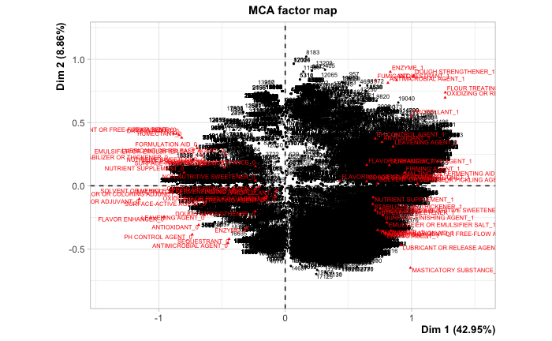

```r
plot(dim_reduction, cex = 0.5)
```